# Revisão de Teoria de Finanças

Conceitos fundamentais para a prova

Autor

Data de Publicação

10 de abril de 2025

# 1 Introdução

Este documento contém uma revisão dos principais conceitos de Teoria de Finanças que serão abordados na prova. Utilizamos o sistema **Quarto** para criar este documento, demonstrando como esta ferramenta pode ser útil para:

- Escrever conteúdo acadêmico com formatação profissional
- Incorporar equações matemáticas complexas
- Incluir visualizações e análises geradas por código R
- Criar documentos reproduzíveis para pesquisa

Vamos revisar os seguintes tópicos:

1. Covariância e correlação entre ativos
2. Modelo de precificação de ativos (CAPM)
3. Teoria de otimização de carteiras (Markowitz)
4. Fronteira eficiente

# 2 Conceitos Estatísticos em Finanças

## 2.1 Covariância e Correlação

A **covariância** mede como dois ativos se movimentam em relação um ao outro. É definida matematicamente como:

$$\text{Cov}(R_A, R_B) = E[(R_A - E[R_A])(R_B - E[R_B])]$$

A **correlação** é uma versão normalizada da covariância, variando entre -1 e +1:

$$\rho_{A,B} = \frac{\text{Cov}(R_A, R_B)}{\sigma_A \sigma_B}$$

Onde:

- $\rho_{A,B}$ é o coeficiente de correlação entre os ativos A e B
- $\sigma_A$ e $\sigma_B$ são os desvios-padrão dos retornos dos ativos A e B

**Código**

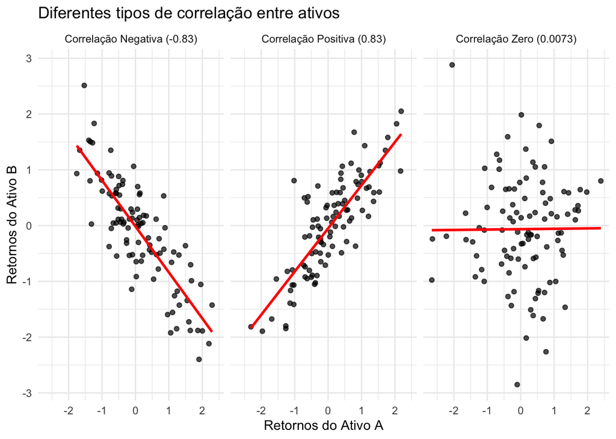

Figura 1: Exemplo de diferentes níveis de correlação entre ativos

```r
# Carregar pacotes necessários
library(tidyverse) # Conjunto de pacotes para manipulação e visualização de dados
library(ggplot2) # Pacote específico para gráficos

# PASSO 1: Criar dados simulados para demonstrar diferentes tipos de correlação
set.seed(123) # Define uma "semente" para garantir que os números aleatórios sejam os mesmos sempre
n <- 100 # Número de observações para cada exemplo

# PASSO 2: Criar dados com correlação positiva forte (próxima de +1)
# Geramos x_pos aleatoriamente, e depois criamos y_pos relacionado a x_pos
x_pos <- rnorm(n) # Gera n valores aleatórios de uma distribuição normal
# Multiplicamos x_pos por 0.8 e adicionamos um pouco de ruído para criar uma relação linear positiva
y_pos <- x_pos * 0.8 + rnorm(n, sd = 0.5)
cor_pos <- round(cor(x_pos, y_pos), 2) # Calcula e arredonda a correlação real

# PASSO 3: Criar dados com correlação negativa forte (próxima de -1)
# Mesmo processo, mas com sinal negativo para criar relação inversa
x_neg <- rnorm(n)
y_neg <- x_neg * -0.8 + rnorm(n, sd = 0.5) # Note o sinal negativo aqui
cor_neg <- round(cor(x_neg, y_neg), 2)

# PASSO 4: Criar dados sem correlação (próximo de 0)
# Este processo é mais complexo para garantir correlação zero
x_zero <- rnorm(n)
y_aux <- rnorm(n)

# Usamos um processo matemático chamado ortogonalização para garantir correlação zero
# A projeção de y_aux em x_zero representa a parte de y_aux explicada por x_zero
proj <- sum(y_aux * x_zero) / sum(x_zero^2) * x_zero

# Subtraindo a projeção, obtemos um vetor ortogonal (perpendicular) a x_zero
y_zero <- y_aux - proj # Isto garante correlação zero por construção matemática
cor_zero <- round(cor(x_zero, y_zero), 4)

# Normalizamos para manter a variabilidade semelhante aos outros exemplos
y_zero <- y_zero * sd(y_aux) / sd(y_zero)
cor_zero <- round(cor(x_zero, y_zero), 4)

# PASSO 5: Organizar os dados para visualização
# Criamos três data frames separados, um para cada tipo de correlação
data_pos <- data.frame(
  x = x_pos,
  y = y_pos,
  tipo = paste0("Correlação Positiva (", cor_pos, ")")
)

data_neg <- data.frame(
  x = x_neg,
  y = y_neg,
  tipo = paste0("Correlação Negativa (", cor_neg, ")")
)

data_zero <- data.frame(
  x = x_zero,
  y = y_zero,
  tipo = paste0("Correlação Zero (", cor_zero, ")")
)

# Combinar todos os data frames em um único
all_data <- rbind(data_pos, data_neg, data_zero)

# PASSO 6: Criar visualização
# Usamos ggplot2 para criar um gráfico de dispersão para cada tipo de correlação
ggplot(all_data, aes(x = x, y = y)) +
  geom_point(alpha = 0.7) + # Pontos semi-transparentes
  geom_smooth(method = "lm", se = FALSE, color = "red") + # Linha de tendência sem intervalo de confiança
  facet_wrap(~tipo) + # Divide em 3 painéis, um para cada tipo
  theme_minimal() + # Tema minimalista para o gráfico
  labs(
    title = "Diferentes tipos de correlação entre ativos",
    x = "Retornos do Ativo A",
    y = "Retornos do Ativo B"
  )
```

A Figura 1 mostra três cenários distintos de correlação entre ativos. Em finanças, entender estas relações é fundamental para a diversificação eficiente de carteiras.

## 2.2 Importância para Diversificação

A correlação entre ativos determina o grau de diversificação que pode ser alcançado em uma carteira:

- Correlação positiva: menor benefício de diversificação
- Correlação próxima de zero: maior benefício de diversificação
- Correlação negativa: benefício máximo de diversificação

# 3 Modelo de Precificação de Ativos (CAPM)

O modelo CAPM (*Capital Asset Pricing Model*), desenvolvido por Sharpe, Lintner e Mossin, estabelece uma relação linear entre o retorno esperado de um ativo e seu risco sistemático, medido pelo beta (Sharpe, 1964).

## 3.1 Equação Fundamental do CAPM

$$E(R_i) = R_f + \beta_i [E(R_m) - R_f]$$

Sendo:

- $E(R_i)$ = retorno esperado do ativo $i$
- $R_f$ = taxa livre de risco
- $\beta_i$ = beta do ativo $i$ (medida de risco sistemático)
- $E(R_m)$ = retorno esperado do mercado
- $[E(R_m) - R_f]$ = prêmio de risco do mercado

## 3.2 Cálculo do Beta

O beta de um ativo é calculado pela seguinte fórmula:

$$\beta_i = \frac{\text{Cov}(R_i, R_m)}{\text{Var}(R_m)}$$

## 3.3 Interpretação do Beta

O beta também pode ser interpretado como a sensibilidade de um ativo às condições econômicas que afetam o mercado como um todo. Setores como tecnologia e consumo discricionário tendem a ter betas mais altos, enquanto setores como utilities e bens de consumo básico tendem a ter betas mais baixos.

## 3.4 Limitações do Beta como Medida de Risco

É importante entender que o beta:

1. É calculado com base em dados históricos e pode não prever adequadamente comportamentos futuros.
2. Assume uma relação estável entre o ativo e o mercado ao longo do tempo.
3. Pode variar significativamente dependendo do período de amostragem e da frequência dos dados.
4. Não captura riscos específicos do ativo que não estão correlacionados com o mercado.

**Código**

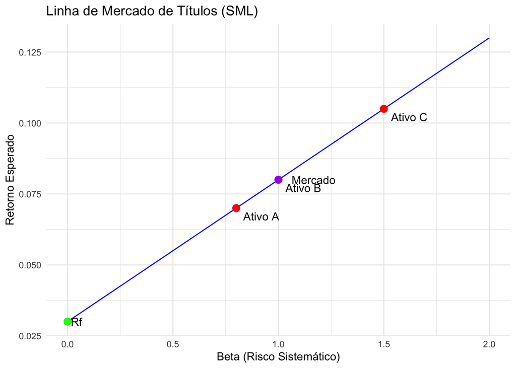

Figura 2: Linha de Mercado de Títulos (SML) do modelo CAPM

```r
# PASSO 1: Definir os parâmetros para o gráfico SML
betas <- seq(0, 2, by = 0.01) # Sequência de betas de 0 a 2
risk_free <- 0.03 # Taxa livre de risco (3%)
market_premium <- 0.05 # Prêmio de risco do mercado (5%)

# PASSO 2: Calcular retornos esperados para cada beta usando a equação do CAPM
# E(Ri) = Rf + βi × (E(Rm) - Rf)
expected_returns <- risk_free + betas * market_premium

# PASSO 3: Criar dataframe para o gráfico
sml_data <- data.frame(
  Beta = betas,
  Retorno = expected_returns
)

# PASSO 4: Adicionar alguns pontos específicos para ilustrar ativos individuais
points <- data.frame(
  Beta = c(0.8, 1.0, 1.5), # Três betas diferentes (defensivo, neutro, agressivo)
  # Calculamos os retornos esperados para cada beta
  Retorno = c(0.03 + 0.8 * 0.05, 0.03 + 1.0 * 0.05, 0.03 + 1.5 * 0.05),
  Ativo = c("Ativo A", "Ativo B", "Ativo C")
)

# PASSO 5: Criar o gráfico da SML
ggplot() +
  # Linha SML principal
  geom_line(data = sml_data, aes(x = Beta, y = Retorno), color = "blue") +

  # Adicionar pontos para ativos específicos
  geom_point(data = points, aes(x = Beta, y = Retorno), color = "red", size = 3) +
  geom_text(
    data = points, aes(x = Beta, y = Retorno, label = Ativo),
    hjust = -0.2, vjust = 1.5
  ) +

  # Marcar a taxa livre de risco (β = 0)
  geom_point(aes(x = 0, y = risk_free), color = "green", size = 3) +
  geom_text(aes(x = 0, y = risk_free, label = "Rf"), hjust = -0.3) +

  # Marcar o retorno do mercado (β = 1)
  geom_point(aes(x = 1, y = risk_free + market_premium), color = "purple", size = 3) +
  geom_text(aes(x = 1, y = risk_free + market_premium, label = "Mercado"), hjust = -0.3) +

  # Personalizar o gráfico
  theme_minimal() +
  labs(
    title = "Linha de Mercado de Títulos (SML)",
    x = "Beta (Risco Sistemático)",
    y = "Retorno Esperado"
  )
```

Na Figura 2, podemos observar a Linha de Mercado de Títulos (SML) do modelo CAPM, que representa graficamente a relação entre risco sistemático (beta) e retorno esperado.

# 4 Teoria de Otimização de Carteiras de Markowitz

Harry Markowitz (1952) desenvolveu a Teoria Moderna de Carteiras, que demonstra como investidores podem otimizar seus retornos para um dado nível de risco (Markowitz, 1952).

## 4.1 Princípios Fundamentais

1. Os investidores são avessos ao risco.
2. O risco de uma carteira não é a média ponderada dos riscos individuais.
3. A diversificação pode reduzir o risco sem necessariamente reduzir o retorno.

## 4.2 Fórmulas para Carteiras com Dois Ativos

Para uma carteira com dois ativos (A e B), temos:

**Retorno esperado da carteira:**

$$E(R_p) = w_A E(R_A) + w_B E(R_B)$$

**Variância da carteira:**

$$\sigma_p^2 = w_A^2 \sigma_A^2 + w_B^2 \sigma_B^2 +
2 w_A w_B \sigma_A \sigma_B \rho_{A,B}$$

Onde:

- $w_A$ e $w_B$ são os pesos dos ativos A e B na carteira
- $\sigma_A$ e $\sigma_B$ são os desvios-padrão dos ativos A e B
- $\rho_{A,B}$ é a correlação entre os ativos A e B

## 4.3 Fronteira Eficiente

A fronteira eficiente é o conjunto de carteiras que oferecem o maior retorno esperado para um dado nível de risco, ou o menor risco para um dado nível de retorno.

**Código**

[figure not shown]

Figura 3: Fronteira Eficiente de Markowitz - Abordagem Analítica para Dois Ativos

```r
# PASSO 1: Definimos os parâmetros dos dois ativos
mu_1 <- 0.10 # Retorno esperado do ativo 1 (10% ao ano, por exemplo)
sigma_1 <- 0.20 # Risco (desvio padrão) do ativo 1 (20% ao ano)
mu_2 <- 0.15 # Retorno esperado do ativo 2 (15% ao ano)
sigma_2 <- 0.30 # Risco (desvio padrão) do ativo 2 (30% ao ano)
rho <- 0.3 # Correlação entre os ativos (30%)

# PASSO 2: Criar pesos para todas as combinações possíveis entre os dois ativos
# Variamos o peso do ativo 1 de 0% a 100% em incrementos de 1%
weights <- seq(0, 1, by = 0.01) # 101 combinações diferentes

# PASSO 3: Calcular o retorno esperado de cada combinação de carteira
# Para dois ativos: E(Rp) = w1*E(R1) + w2*E(R2), onde w2 = 1-w1
portfolio_return <- weights * mu_1 + (1 - weights) * mu_2

# PASSO 4: Calcular o risco (variância) de cada combinação de carteira
# Para dois ativos: Var(p) = w1²*Var1 + w2²*Var2 + 2*w1*w2*Cov(1,2)
# Onde Cov(1,2) = rho*sigma1*sigma2
portfolio_variance <- weights^2 * sigma_1^2 + (1 - weights)^2 * sigma_2^2 +
  2 * weights * (1 - weights) * sigma_1 * sigma_2 * rho

# Convertemos variância para desvio padrão (para usar nas mesmas unidades que os retornos)
portfolio_sd <- sqrt(portfolio_variance)

# PASSO 5: Organizar os resultados em um data frame para visualização
portfolio_data <- data.frame(
  Peso_Ativo1 = weights,
  Retorno = portfolio_return,
  Risco = portfolio_sd
)

# PASSO 6: Identificar a carteira de variância mínima
# Esta é a carteira com o menor valor na coluna "Risco"
min_var_idx <- which.min(portfolio_data$Risco)
min_var_portfolio <- portfolio_data[min_var_idx, ]

# PASSO 7: Criar o gráfico da fronteira eficiente
ggplot(portfolio_data, aes(x = Risco, y = Retorno)) +
  # Linha da fronteira
  geom_path(size = 1.2, color = "blue") +

  # Destacar a carteira de variância mínima
  geom_point(data = min_var_portfolio, color = "red", size = 3) +
  geom_text(
    data = min_var_portfolio,
    aes(label = "Carteira de Variância Mínima"),
    hjust = -0.1, vjust = -0.8
  ) +

  # Destacar os pontos que representam 100% em cada ativo
  geom_point(data = portfolio_data[c(1, 101), ], color = "green", size = 3) +
  geom_text(
    data = portfolio_data[c(1, 101), ],
    aes(label = c("100% Ativo 1", "100% Ativo 2")),
    hjust = c(1.1, -0.1), vjust = c(0, 0)
  ) +

  # Personalizar o visual do gráfico
  theme_minimal() +
  labs(
    title = "Curva de Combinações de Carteiras com Dois Ativos",
    subtitle = paste("Correlação:", rho),
    x = "Risco (Desvio Padrão)",
    y = "Retorno Esperado"
  )
```

## 4.4 Comparação entre Abordagens para Cálculo da Fronteira Eficiente

Existem duas maneiras principais de calcular a fronteira eficiente:

### 4.4.1 Abordagem Analítica para Dois Ativos (vista acima)

O gráfico anterior mostra a fronteira eficiente calculada de forma **analítica** para dois ativos, onde:

- Todas as combinações possíveis de pesos são calculadas diretamente
- As fórmulas fechadas para retorno e risco são aplicadas a cada combinação
- A fronteira é traçada diretamente a partir desses cálculos

**Vantagens desta abordagem:**

- Simples de implementar e entender
- Computacionalmente eficiente para apenas dois ativos
- Não requer técnicas de otimização avançadas

**Limitações:**

- Funciona apenas para dois ativos
- Não é facilmente escalável para carteiras maiores

### 4.4.2 Abordagem de Otimização Formal (mostrada a seguir)

No próximo exemplo, veremos uma implementação usando **otimização formal** via programação quadrática, onde:

- O problema é formulado matematicamente como minimização de risco para cada nível de retorno
- Um algoritmo de otimização encontra os pesos ótimos
- A fronteira é construída ponto a ponto resolvendo múltiplos problemas de otimização

Esta abordagem é necessária para carteiras com três ou mais ativos, como veremos a seguir.

**Código**

```r
# Carregamos os pacotes necessários
library(quadprog) # Pacote para resolver problemas de programação quadrática

#----------------------------------------------------------------
# PARTE 1: DEFINIÇÃO DO PROBLEMA DE OTIMIZAÇÃO
#----------------------------------------------------------------

# Vamos criar um exemplo com 3 ativos para demonstrar a otimização formal
# Definimos os parâmetros dos ativos (retornos esperados e matriz de covariância)
set.seed(123) # Para reprodutibilidade

# Retornos esperados dos ativos
mu <- c(0.08, 0.12, 0.15)
names(mu) <- c("Ativo A", "Ativo B", "Ativo C")

# Para a matriz de covariância, vamos defini-la diretamente:
# Desvios-padrão dos ativos
sigma <- c(0.16, 0.20, 0.28)
# Matriz de correlações (simétrica, diagonal = 1)
corr_matrix <- matrix(c(
  1.00, 0.30, 0.10,
  0.30, 1.00, 0.20,
  0.10, 0.20, 1.00
), nrow = 3, byrow = TRUE)

# Construção da matriz de covariância a partir das correlações e desvios-padrão
# Fórmula: Cov(i,j) = Corr(i,j) * sigma_i * sigma_j
cov_matrix <- matrix(0, 3, 3)
for (i in 1:3) {
  for (j in 1:3) {
    cov_matrix[i, j] <- corr_matrix[i, j] * sigma[i] * sigma[j]
  }
}

# Exibindo os dados
cat("Retornos esperados:\n")
```

```
Retornos esperados:
```

**Código**

```r
print(mu)
```

```
Ativo A Ativo B Ativo C
   0.08    0.12    0.15
```

**Código**

```r
cat("\nMatriz de covariâncias:\n")
```

```
Matriz de covariâncias:
```

**Código**

```r
print(round(cov_matrix, 4))
```

```
       [,1]   [,2]   [,3]
[1,] 0.0256 0.0096 0.0045
[2,] 0.0096 0.0400 0.0112
[3,] 0.0045 0.0112 0.0784
```

**Código**

```r
#----------------------------------------------------------------
# PARTE 2: FUNÇÃO DE OTIMIZAÇÃO DA CARTEIRA
#----------------------------------------------------------------

#' Calcula a carteira de variância mínima para um dado retorno alvo
#' @param target_return Retorno esperado alvo
#' @param mu Vetor de retornos esperados dos ativos
#' @param cov_matrix Matriz de covariâncias dos ativos
#' @return Lista com pesos ótimos, retorno esperado e risco da carteira
optimize_portfolio <- function(target_return, mu, cov_matrix) {
  # Número de ativos
  n_assets <- length(mu)

  # FORMULAÇÃO DO PROBLEMA DE PROGRAMAÇÃO QUADRÁTICA
  # Problema: Minimizar w'Σw sujeito a:
  # 1. w'μ = target_return (restrição de retorno alvo)
  # 2. sum(w) = 1 (restrição de orçamento - pesos somam 1)

  # Termo quadrático (matriz D na função solve.QP)
  Dmat <- 2 * cov_matrix # O 2 é necessário pela formulação do solve.QP

  # Termo linear é zero neste caso, pois estamos minimizando w'Σw
  dvec <- rep(0, n_assets)

  # Matriz de restrições (A_eq na formulação padrão)
  # Cada linha representa uma restrição linear
  # 1ª linha: w'μ = target_return (restrição de retorno)
  # 2ª linha: sum(w) = 1 (restrição de orçamento)
  Amat <- cbind(mu, rep(1, n_assets))

  # Lado direito das restrições
  bvec <- c(target_return, 1)

  # O solve.QP requer que as restrições sejam na forma A'w >= b
  # Mas queremos A'w = b, então adicionamos também -A'w >= -b
  Amat <- cbind(Amat, -Amat)
  bvec <- c(bvec, -bvec)

  # Resolver o problema de otimização quadrática
  # w é a solução que minimiza w'Σw sujeito às restrições
  result <- try(solve.QP(Dmat, dvec, t(Amat), bvec, meq = 2), silent = TRUE)

  if (inherits(result, "try-error")) {
    return(NULL) # Retorna NULL se a otimização falhar
  }

  # Extrair os pesos ótimos
  weights <- result$solution
  names(weights) <- names(mu)

  # Calcular o risco (desvio padrão) da carteira
  risk <- sqrt(t(weights) %*% cov_matrix %*% weights)[1, 1]

  # Verificar se o retorno está correto (pode haver diferenças numéricas pequenas)
  actual_return <- sum(weights * mu)

  return(list(
    weights = weights,
    return = actual_return,
    risk = risk
  ))
}

#----------------------------------------------------------------
# PARTE 3: COMPUTAR A FRONTEIRA EFICIENTE
#----------------------------------------------------------------

# Encontrar a carteira de variância mínima (MVP)
# Formulamos como um problema de otimização irrestrita (sem restrição de retorno)
# Para isso, usamos gradientes da variância = 0 e a restrição de que os pesos somam 1
# A fórmula fechada para os pesos do MVP é: w = (Σ^(-1) * 1) / (1' * Σ^(-1) * 1)

# Vetor de uns
ones <- rep(1, length(mu))

# Cálculo analítico dos pesos da carteira de variância mínima
inv_cov <- solve(cov_matrix)
mvp_weights <- (inv_cov %*% ones) / (t(ones) %*% inv_cov %*% ones)[1, 1]
names(mvp_weights) <- names(mu)
mvp_return <- sum(mvp_weights * mu)
mvp_risk <- sqrt(t(mvp_weights) %*% cov_matrix %*% mvp_weights)[1, 1]

cat("\nCarteira de Variância Mínima:\n")
```

```
Carteira de Variância Mínima:
```

**Código**

```r
cat("Pesos: ", round(mvp_weights, 4), "\n")
```

```
Pesos:  0.5744 0.2673 0.1583
```

**Código**

```r
cat("Retorno: ", round(mvp_return, 4), "\n")
```

```
Retorno:  0.1018
```

**Código**

```r
cat("Risco: ", round(mvp_risk, 4), "\n")
```

```
Risco:  0.1341
```

**Código**

```r
# Gerar pontos na fronteira eficiente
# Definimos uma sequência de retornos alvo acima do retorno da MVP
# e calculamos a carteira ótima para cada retorno alvo
max_return <- max(mu)
target_returns <- seq(mvp_return, max_return, length.out = 50)

# Data frame para armazenar os resultados
frontier_points <- data.frame(
  return = numeric(length(target_returns)),
  risk = numeric(length(target_returns))
)

# Para cada retorno alvo, calculamos a carteira ótima
for (i in seq_along(target_returns)) {
  target <- target_returns[i]
  opt_portfolio <- optimize_portfolio(target, mu, cov_matrix)

  if (!is.null(opt_portfolio)) {
    frontier_points$return[i] <- opt_portfolio$return
    frontier_points$risk[i] <- opt_portfolio$risk
  }
}

# Remover pontos inválidos (se houver)
frontier_points <- frontier_points[!is.na(frontier_points$risk), ]

#----------------------------------------------------------------
# PARTE 4: VISUALIZAÇÃO DA FRONTEIRA EFICIENTE
#----------------------------------------------------------------

# Calculamos também as carteiras de ativo único para referência
single_asset_portfolios <- data.frame(
  asset = names(mu),
  return = mu,
  risk = sigma
)

# Criar o gráfico da fronteira eficiente
ggplot() +
  # Fronteira eficiente
  geom_path(
    data = frontier_points,
    aes(x = risk, y = return),
    color = "blue", size = 1.2
  ) +
  # Carteira de variância mínima
  geom_point(aes(x = mvp_risk, y = mvp_return),
    color = "red", size = 4
  ) +
  geom_text(
    aes(
      x = mvp_risk, y = mvp_return,
      label = "Carteira de Variância Mínima"
    ),
    hjust = -0.1, vjust = -0.8
  ) +
  # Ativos individuais
  geom_point(
    data = single_asset_portfolios,
    aes(x = risk, y = return),
    color = "green", size = 3
  ) +
  geom_text(
    data = single_asset_portfolios,
    aes(x = risk, y = return, label = asset),
    hjust = -0.1, vjust = 0
  ) +
  # Personalização do gráfico
  theme_minimal() +
  labs(
    title = "Fronteira Eficiente de Markowitz",
    subtitle = "Calculada por otimização quadrática formal",
    x = "Risco (Desvio Padrão)",
    y = "Retorno Esperado",
    caption = "Otimização implementada com o pacote quadprog"
  )

#----------------------------------------------------------------
# PARTE 5: EXPLICAÇÃO CONCEITUAL
#----------------------------------------------------------------

cat("\nEXPLICAÇÃO DO PROBLEMA DE OTIMIZAÇÃO DE MARKOWITZ:\n")
```

```
EXPLICAÇÃO DO PROBLEMA DE OTIMIZAÇÃO DE MARKOWITZ:
```

**Código**

```r
cat("1. Buscamos minimizar o risco (variância) para cada nível de retorno esperado\n")
```

```
1. Buscamos minimizar o risco (variância) para cada nível de retorno esperado
```

**Código**

```r
cat("2. Formula-se como um problema de programação quadrática\n")
```

```
2. Formula-se como um problema de programação quadrática
```

**Código**

```r
cat("3. A fronteira eficiente contém todas as carteiras ótimas\n")
```

```
3. A fronteira eficiente contém todas as carteiras ótimas
```

**Código**

```r
cat("4. A carteira de variância mínima é um ponto especial da fronteira\n")
```

```
4. A carteira de variância mínima é um ponto especial da fronteira
```

**Código**

```
5. Acima da carteira de variância mínima, maior retorno implica em maior risco
```

[figure not shown]

```r
cat("5. Acima da carteira de variância mínima, maior retorno implica em maior risco\n")
```

## 4.5 Carteira de Variância Mínima

A carteira de variância mínima, destacada em vermelho nos gráficos de fronteira eficiente, representa a carteira com o menor risco possível dada a combinação dos ativos disponíveis.

## 4.6 Relação com o CAPM

A fronteira eficiente é expandida com a introdução de um ativo livre de risco, criando a Linha de Mercado de Capitais (CML). Segundo o CAPM, todos os investidores manterão uma combinação da carteira de mercado e o ativo livre de risco.

# 5 Aplicações Práticas

As teorias discutidas neste documento têm aplicações práticas importantes:

1. **Gestão de investimentos**: Aplicação direta na construção de carteiras otimizadas.
2. **Avaliação de desempenho**: Benchmarking baseado em risco.
3. **Precificação de ativos**: Estimativa do retorno exigido em investimentos.

Como vimos na seção de Seção 3, o modelo CAPM oferece uma estrutura para determinar o retorno esperado de um ativo baseado em seu risco sistemático.

# 6 Conclusão

Neste documento, revisamos conceitos fundamentais da Teoria de Finanças que serão abordados na prova:

- Covariância e correlação entre ativos (ver Seção 2.1)
- Modelo CAPM e precificação de ativos (ver Seção 3)
- Teoria de Markowitz e otimização de carteiras (ver Seção 4)
- Fronteira eficiente e gestão de risco (ver Seção 4.3)

Estes conceitos formam a base do entendimento moderno sobre investimentos e gestão de riscos em finanças.

# 7 Dicas para a Prova

Ao estudar estes conceitos para a prova, lembre-se de:

1. **Foco nas fórmulas e suas interpretações**: Entenda o significado de cada componente nas equações do CAPM e da Teoria de Markowitz.
2. **Interpretação gráfica**: Saiba explicar o significado da SML e da fronteira eficiente, e como os pontos nestes gráficos devem ser interpretados.
3. **Aplicações práticas**: Relacione os conceitos teóricos com aplicações reais em gestão de investimentos.
4. **Relações entre conceitos**: Entenda como o CAPM e a Teoria de Markowitz se complementam na análise de investimentos.
5. **Limitações dos modelos**: Esteja preparado para discutir as premissas e limitações de cada modelo teórico apresentado.

Boa sorte na prova!

## 7.1 Referências

MARKOWITZ, H. Portfolio selection. **The Journal of Finance**, v. 7, n. 1, p. 77–91, 1952.

SHARPE, W. F. Capital asset prices: A theory of market equilibrium under conditions of risk. **The Journal of Finance**, v. 19, n. 3, p. 425–442, 1964.